### PACKAGE INSTALLATION

If you are new to R, you may need to install some of the dependencies:

```r
if (!requireNamespace("BiocManager", quietly = TRUE))
install.packages("BiocManager")
BiocManager::install()

library(BiocManager)
BiocManager::install(c("caret", "devtools", "data.table", "dplyr", "furrr", "future", "future.apply",
  "ggplot2", "grDevices", "gridExtra", "igraph", "irlba", "janitor", "Matrix", "methods",
  "plotly", "plyr", "purrr", "randomForest", "rhdf5", "rtracklayer", "scales", "stats", "stringr",
  "tibble", "tidyr", "umap", "utils"))
```

Next, install a few additional dependencies found on Github, including amethyst itself.

```r
devtools::install_github("JinmiaoChenLab/Rphenograph")
devtools::install_github("KrishnaswamyLab/MAGIC/Rmagic")
devtools::install_github("lrylaarsdam/amethyst")
```

Now load libraries into R:

```r
library(amethyst)
library(data.table)
library(ggplot2)
library(dplyr)
library(tibble)
library(tidyr)
library(plyr)
library(future)
library(furrr)
library(purrr)
library(cowplot)
library(pheatmap)
```

### LOADING PRACTICE DATA

This vignette comes with a toy dataset of 50 high-coverage cells derived from the human brain cortex. CpH methylation is highly relevant in the brain, but processing this data can take a long time as there are over 1 billion sites in the human genome. To make this illustration quickly run-able on any local computer, we have already done initial processing for computationally-intensive steps. These can be downloaded with a pre-made workspace in the next section. To do all steps from scratch, we recommend going through the CpG-focused PBMC vignette.

- Note: By default, data will download to the ~/Downloads folder. Change if a different directory is desired.

```r
# h5 file containing base-level CG methylation information. This file is 11 GB and not necessarily needed for this tutorial, but available if desired.
# download.file("https://adeylabopen.s3.us-west-2.amazonaws.com/amethyst/brain_vignette.h5", "./brain_vignette.h5", method = "curl")
# workspace containing initial CH processing steps
download.file("https://adeylabopen.s3.us-west-2.amazonaws.com/amethyst/brain_vignette_workspace.RData", "~/Downloads/brain_vignette_workspace.RData", method = "curl")
# metadata files
download.file("https://raw.githubusercontent.com/lrylaarsdam/amethyst/main/brain_vignette/brain_vignette_cellInfo.txt", "~/Downloads/brain_vignette_cellInfo.txt")
download.file("https://raw.githubusercontent.com/lrylaarsdam/amethyst/main/brain_vignette/brain_vignette.annot", "~/Downloads/brain_vignette.annot", method = "curl")
```

### CONSTRUCTING THE AMETHYST OBJECT

First, we must construct an amethyst object, which stores the path to the h5 file as well as a lot of other information that will be calculated downstream. This has already been initialized with the createObject command in the process of pre-running mCH data. Load the workspace to see a summary of the object so far.

```r
# obj <- createObject
load("~/Downloads/brain_vignette_workspace.RData")
summary(obj)
```

```
##   Length    Class     Mode
##        1 amethyst       S4
```

Next, we need to add metadata about each cell. Useful metadata includes quality control metrics contained in the .cellInfo.txt intermediate output or .annot files, if using the Adey lab workflow. We also need to specify the location of the h5 file containing site-level methylation data for each barcode. In this case, every barcode belongs to the same h5 file, but an unlimited number of h5 files can be used in the same object. Row names are barcodes and the “paths” column specifies each path.

```r
obj <- addCellInfo(obj, file = "~/Downloads/brain_vignette_cellInfo.txt")
obj <- addAnnot(obj, file = "~/Downloads/brain_vignette.annot", name = "method")
obj@h5paths <- data.frame(row.names = rownames(obj@metadata), paths = rep("~/Downloads/brain_vignette.h5", length(rownames(obj@metadata))))
head(obj@metadata)
```

```
##                                    cov  cg_cov mcg_pct   ch_cov mch_pct method
## GGCTGGCTCTCCAATTCCATGCAGAATT 106957445 4877184   72.10 86856968    3.89     LA
## GACTAGCATTCCAATTCCATACACTAAG 116391399 4833685   72.58 93413152    1.01     LA
## ATTGAGGATACTACTGCAAGATGGCATG 110343538 4985043   72.10 88886888    1.75     LA
## GACTAGCATTATAATCGCGGAGTACTCC 116348506 5219160   74.17 93373829    2.03     LA
## GGTTAGTTGGACGCTTCGTCCATAGAGT 108400287 4716694   75.72 89048039    1.44     LA
## GAAGAGTATTCCAATTCCATGATCTATC 110330950 4718426   68.35 88661571    1.09     LA
```

While not essential, it can be helpful to filter cells right away so downstream functions don’t perform calculations For cells that will not be used. This can easily be done with dplyr logic.

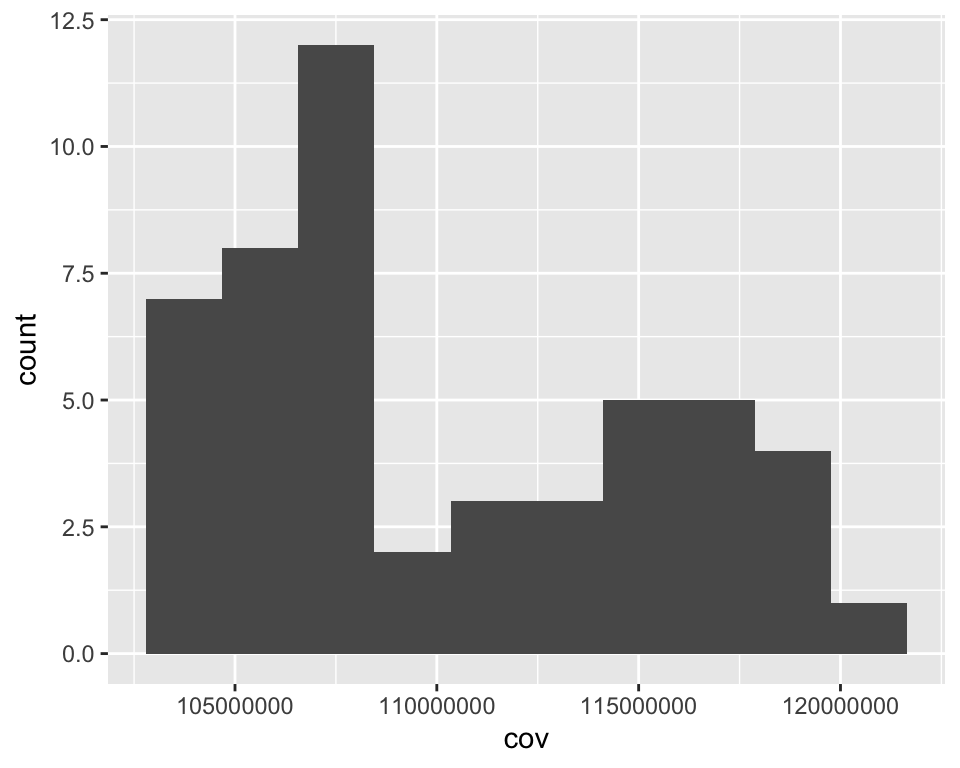

```r
ggplot(obj@metadata, aes(x = cov)) + geom_histogram(bins = 10)
```

```r
obj@metadata <- obj@metadata |> dplyr::filter(cov > 1000000 & mch_pct < 12)
```

The next step is to cluster cells, which we typically do based on methylation values over fixed genomic windows. Initial indexing helps reduce the computational load by determining the locations corresponding to each chromosome in every h5 file and only calculating across one at a time.

*** Note: The output of these steps is already in your workspace. You can run them again if you want, but prepare to wait a while.

```r
obj@index[["chr_cg"]] <- indexChr(obj, type = "CG", threads = 1) # might take up to 5 minutes
obj@genomeMatrices[["cg_100k_score"]] <- makeWindows(obj, stepsize = 100000, type = "CG", metric = "score", threads = 1, index = "chr_cg", nmin = 2) # might take 5-10 minutes
obj@index[["chr_ch"]] <- indexChr(obj, type = "CH", threads = 1)
obj@genomeMatrices[["ch_100k_pct"]] <- makeWindows(obj, stepsize = 100000, type = "CH", metric = "percent", threads = 1, index = "chr_ch", nmin = 5)
```

Next, perform dimensionality reduction with irlba. In this example, the number of requested output dimensions is low because brain_vignette.h5 has 50 cells. If you are unsure how many dimensions to use, the dimEstimate function can help estimate the number needed to explain the desired variance threshold.

```r
set.seed(111)
obj@reductions[["irlba"]] <- runIrlba(obj, genomeMatrices = c("ch_100k_pct", "cg_100k_score"), dims = c(5, 5), replaceNA = c("mch_pct", 0))
```

Now determine cluster membership using the Rphenograph package. *Note: In this example, k_phenograph and neighbors parameters are low because brain_vignette.h5 has 50 cells.

```r
obj@reductions[["irlba_regressed"]] <- regressCovBias(obj, reduction = "irlba")
set.seed(111)
obj <- runCluster(obj, k_phenograph = 10, reduction = "irlba_regressed") # consider increasing k_phenograph to 50 for larger datasets
```

```
## Run Rphenograph starts:
##   -Input data of 50 rows and 10 columns
##   -k is set to 10
```

```
##   Finding nearest neighbors...DONE ~ 0.001 s
##   Compute jaccard coefficient between nearest-neighbor sets...DONE ~ 0.001 s
##   Build undirected graph from the weighted links...DONE ~ 0.006 s
##   Run louvain clustering on the graph ...DONE ~ 0.001 s
```

```
## Run Rphenograph DONE, totally takes 0.00899999999999856s.
```

```
##   Return a community class
##   -Modularity value: 0.6575309
##   -Number of clusters: 5
```

Umap and tsne are dimensionality reduction techniques frequently used to collapse higher-order information into two or three coordinates for visualization of single-cell data. Either (or both method)s can be used as input for dimensionality reduction- based visualization functions like dimFeature.

```r
set.seed(111)
obj <- runUmap(obj, neighbors = 5, dist = 0.01, method = "euclidean", reduction = "irlba_regressed")
obj <- runTsne(obj, perplexity = 5, method = "euclidean", theta = 0.2, reduction = "irlba_regressed")
```

### Visualizing the results

First, plot the UMAP or TSNE coordinates of the cells with the color corresponding to cluster membership.

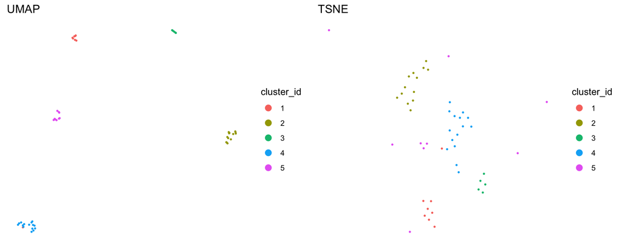

```r
p1 <- dimFeature(obj, colorBy = cluster_id, reduction = "umap") + ggtitle("UMAP")
p2 <- dimFeature(obj, colorBy = cluster_id, reduction = "tsne") + ggtitle("TSNE")
plot_grid(p1, p2)
```

dimFeature uses ggplot logic, so you can easily modify plots as needed. Below is an example of cells divided by a simulated “batch” parameter.

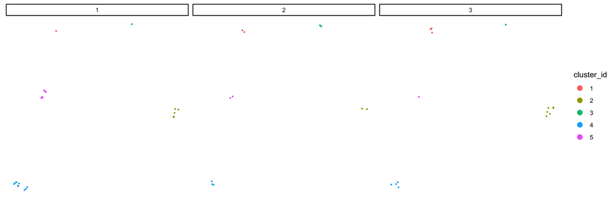

```r
# Adding a random variable "batch" to illustrate faceting
set.seed(111)
obj@metadata$batch <- sample(1:3, nrow(obj@metadata), replace = TRUE)
dimFeature(obj, colorBy = cluster_id) + facet_wrap(vars(batch), nrow = 1) # Batch is simulated to illustrate function utility. Any column in the metadata will work.
```

Optional: If you want to make the umap/tsne plots look nicer, amethyst provides many built-in color palettes:

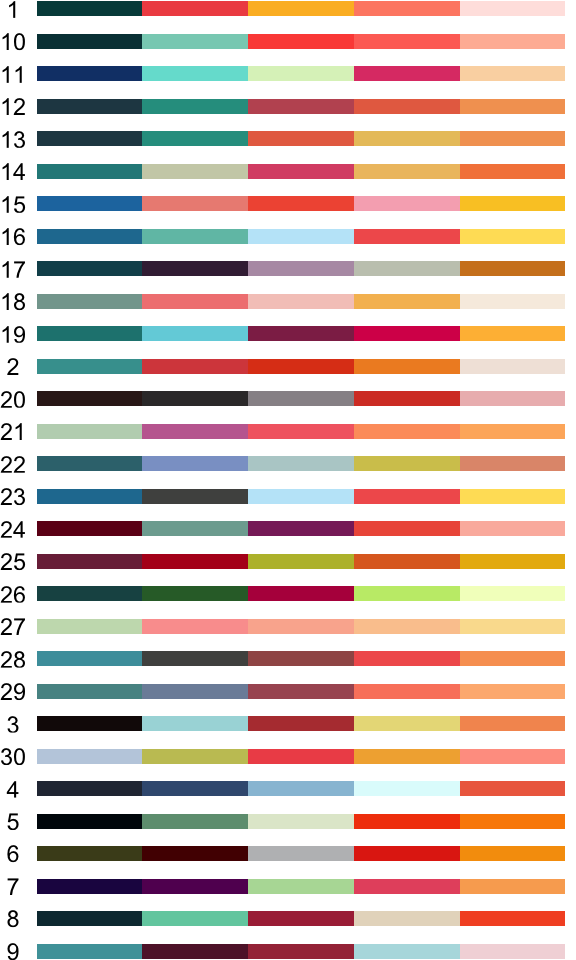

```r
testPalette(output = "swatch", n = length(unique(obj@metadata$cluster_id)))
```

Then define your favorite palette for future use:

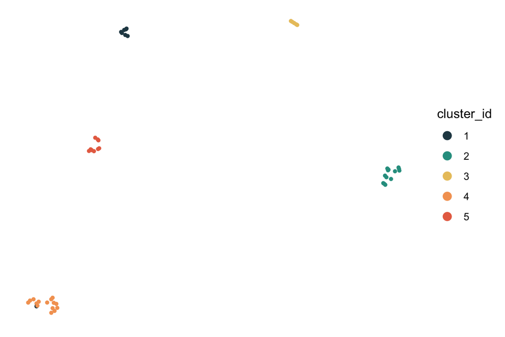

```r
pal <- makePalette(option = 13, n = 5)
dimFeature(obj, colorBy = cluster_id, colors = pal, pointSize = 1)
```

dimFeature is useful for visualizing how the different parameters in the cellInfo file are distributed throughout the UMAP:

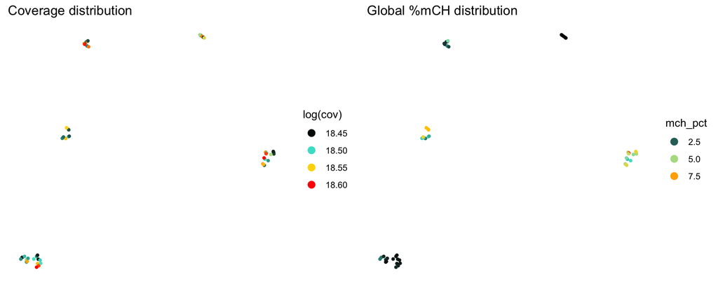

```r
p1 <- dimFeature(obj, colorBy = log(cov), pointSize = 1) + scale_color_gradientn(colors = c("black", "turquoise", "gold", "red")) + ggtitle("Coverage distribution")
p2 <- dimFeature(obj, colorBy = mch_pct, pointSize = 1) + scale_color_gradientn(colors = c("black", "turquoise", "gold", "red")) + ggtitle("Global %mCH distribution")
plot_grid(p1, p2)
```

Show the distribution of cluster membership between samples with sampleComp. Plots can be easily modified with ggplot command logic.

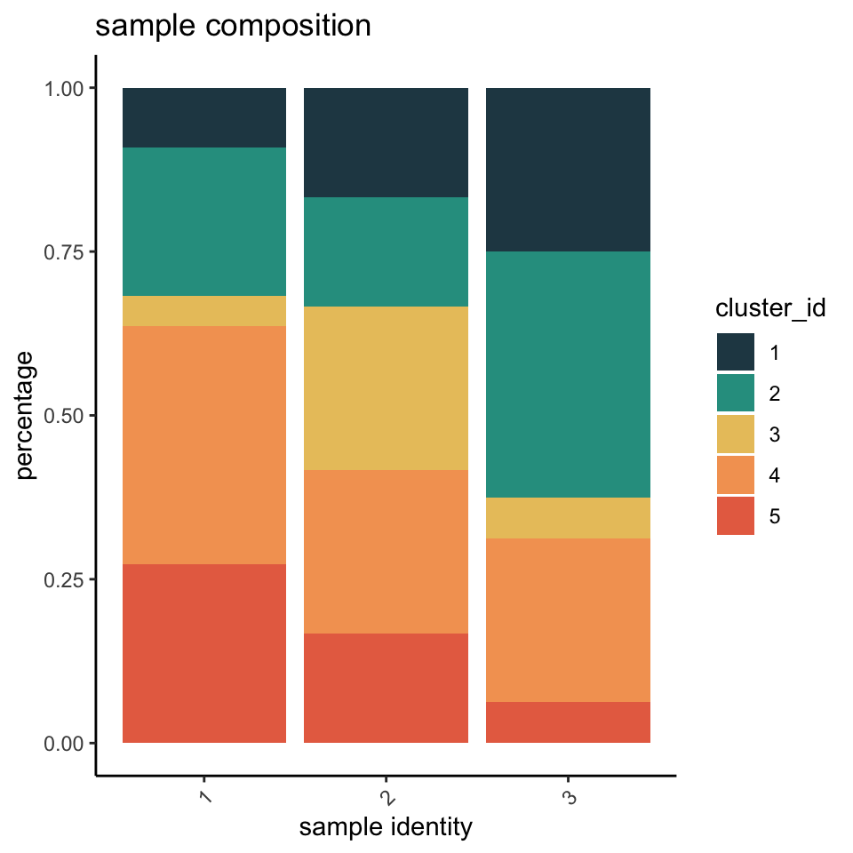

```r
sampleComp(obj, groupBy = "batch", colorBy = "cluster_id", colors = pal)
```

### ANNOTATION

Now that we have clusters, the next step is annotation. There are a couple ways to do this:

1. One useful method is to look at mCG hypomethylation over canonical marker genes. We recommend visualizing mCG patterns over the entire gene body. The first step is to load an annotation file for the reference genome so amethyst knows the coordinates for each gene.

```r
obj@ref <- makeRef("hg38")
```

Next, calculate methylation levels in short genomic windows for each cluster. We recommend 500bp windows, but 1kb are used here since the dataset is smaller.

*** Note: The output of these steps is already in your workspace. You can run them again if you want, but prepare to wait a while.

```r
cluster1kbwindows <- calcSmoothedWindows(obj,
                                         type = "CG",
                                         threads = 1,
                                         step = 1000,
                                         smooth = 3,
                                         genome = "hg38",
                                         index = "chr_cg",
                                         groupBy = "cluster_id",
                                         returnSumMatrix = TRUE, # save sum matrix for DMR analysis
                                         returnPctMatrix = TRUE)
```

Add the percent matrix output to the genomeMatrices slot. This will be used for visualizing methylation patterns over genomic regions with histograM or heatMap functions.

```r
obj@genomeMatrices[["cg_cluster_tracks"]] <- cluster1kbwindows[["pct_matrix"]]
```

Now you can view methylation patterns over key marker genes:

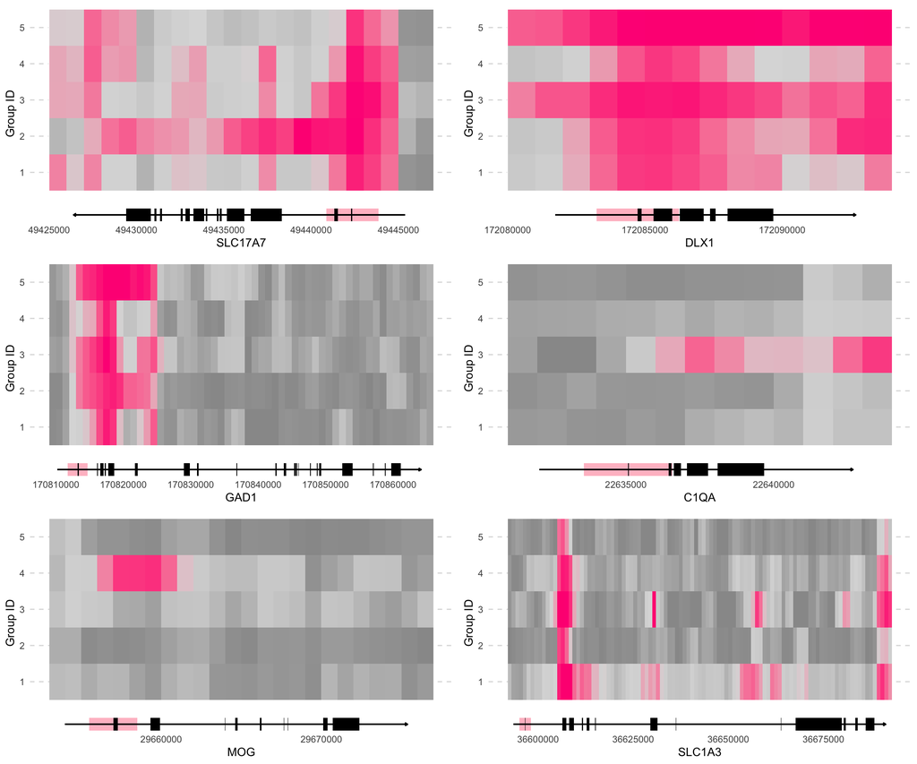

```r
heatMap(obj,
        genes = c("SLC17A7", "DLX1", "GAD1", "C1QA", "MOG", "SLC1A3"),
        matrix = "cg_cluster_tracks",
        nrow = 3,
        legend = FALSE,
        width = 1000) # Width of the genome step, which should be equivalent to the "step" parameter in cluster1kbwindows
```

As you can see from the heatMaps, promoters are often universally hypomethylated or not at the predicted site. Because of this it is often more informative to look at mCG over the entire gene body. In addition to heatMap, this can also be done with the histograM function:

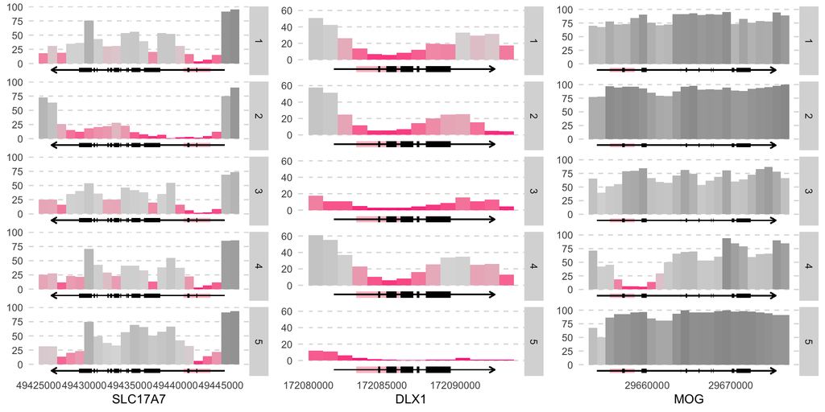

```r
histograM(obj,
        genes = c("SLC17A7", "DLX1", "MOG"),
        matrix = "cg_cluster_tracks",
        legend = FALSE,
        width = 1000)
```

Looking at mCG patterns over key marker genes in this manner can provide sufficient information for cell type annotation. However, the brain uniquely has extremely high levels of mCH in addition to mCG, which can provide further information for cell type annotation. Unlike mCG, this unique methylation signature accumulates across gene bodies and is anticorrelated with expression.

First calculate the mCH levels over a subset of genes that were shown to have differential methylation in the brain (PMCID: PMC8494641) *** Note: The output of these steps is already in your workspace. You can run them again if you want, but prepare to wait a while.

```r
obj@genomeMatrices[["gene_ch"]] <- makeWindows(obj, genes = fetchMarkers("human", "brain"), type = "CH", metric = "percent", threads = 10, index = "chr_ch", nmin = 2) # already run and in workspace
```

Then plot the mCH levels over gene bodies with functions like dotM:

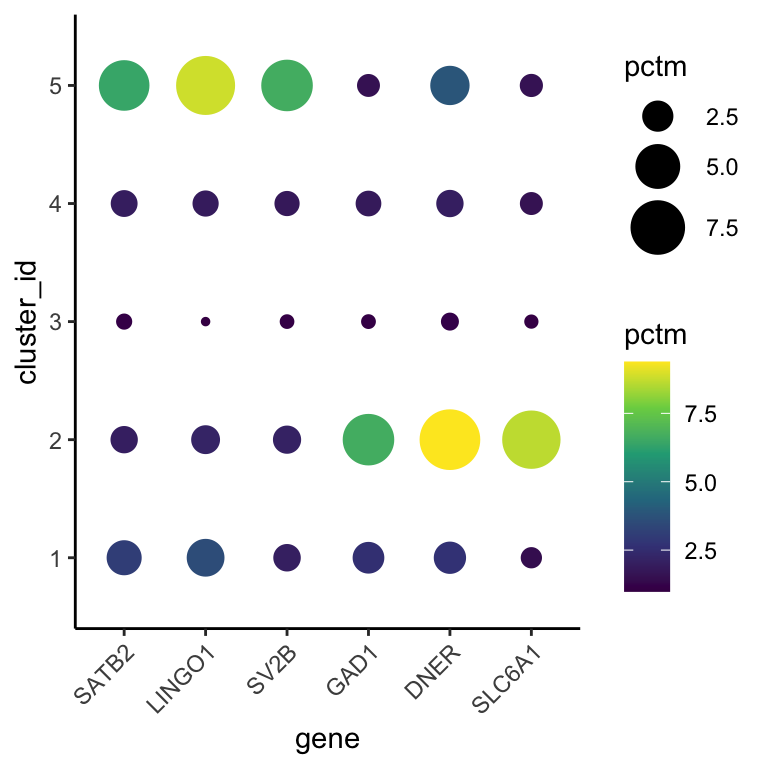

```r
dotM(obj, genes = c("SATB2", "LINGO1", "SV2B", "GAD1", "DNER", "SLC6A1"), groupBy = "cluster_id", matrix = "gene_ch") + scale_size(range = c(1, 10))
```

Based on Liu et al., 2021, we can clearly tell from this dot plot that cluster 5 is inhibitory and 2 is excitatory neurons. Gene body %mCH can also be helpful to view over umap/tsne coordinates or violin plots when annotating cell types.

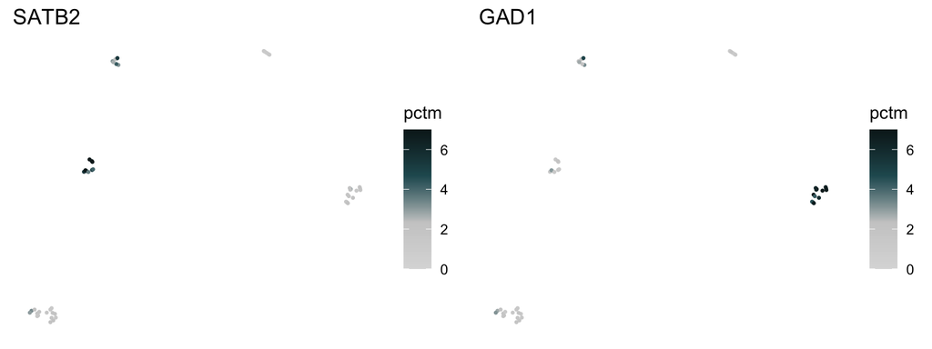

```r
dimM(obj, genes = c("SATB2", "GAD1"), matrix = "gene_ch", pointSize = .5, squish = 7, colors = c("#dbdbdb", "#cccccc", "#265A61", "#0C1E20")) # Squish: set max value. All above will be collapsed.
```

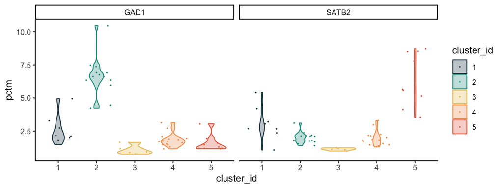

```r
violinM(obj, genes = c("SATB2", "GAD1"), matrix = "gene_ch", groupBy = "cluster_id", colors = pal)
```

It can also be helpful to use a less directed approach when determining differences between groups. The findClusterMarkers function can be used for finding top cluster-specific promoter mCG or gene body mCH differentially methylated genes.

```r
cluster_markers <- findClusterMarkers(obj,
                                      matrix = "gene_ch",
                                      genes = rownames(obj@genomeMatrices[["gene_ch"]]),
                                      threads = 1)
cluster_markers <- cluster_markers |> dplyr::filter(p.adj < 0.05) # Not many results because it's a small dataset
top_hyper_mCH <- cluster_markers |> dplyr::filter(direction == "hypermethylated") |> dplyr::group_by(cluster_id) |> dplyr::top_n(1, wt = p.adj)
```

Another method for cell type annotation is by comparison to an annotated reference. While few exist, there are high-quality references available for brain data. We have aggregated mCH across key genes from PMC9004682. This reference can be downloaded from Github.

```r
download.file("https://raw.githubusercontent.com/lrylaarsdam/amethyst/main/brain_vignette/PMC9004682_5972genes_BA10_ref.RData", "~/Downloads/PMC9004682_5972genes_BA10_ref.RData", method = "curl")
ref <- readRDS("~/Downloads/PMC9004682_5972genes_BA10_ref.RData")
obj@genomeMatrices[["gene_ch_cluster"]] <- aggregateMatrix(obj, matrix = "gene_ch", groupBy = "cluster_id")
```

Now see how aggregated mCH profiles from the reference compare to those of our clusters

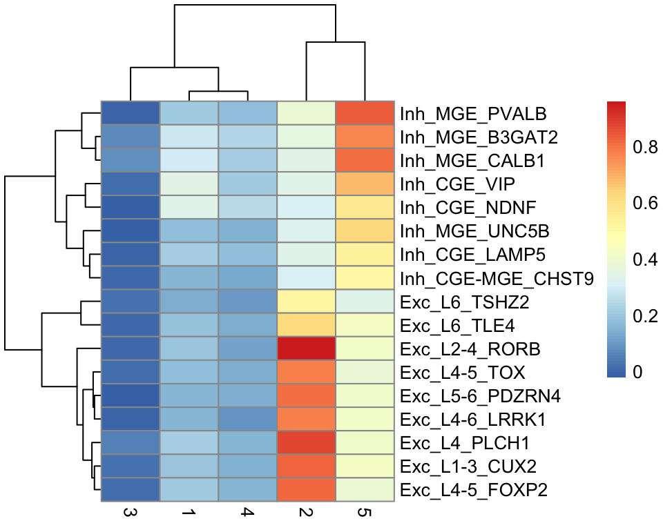

```r
cor <- cor(merge(ref,
                 obj@genomeMatrices[["gene_ch_cluster"]],
                 by = 0) |> tibble::column_to_rownames(var = "Row.names"), use = "pairwise.complete.obs")
cor <- cor[c(1:ncol(ref)), c((ncol(ref) + 1)):ncol(cor)]
pheatmap(cor)
```

As previously suspected, cluster 2 are a mixed population of excitatory neurons, and cluster 5 inhibitory neurons. The other 3 are glia, which we can determine from global %mCH levels. These can be annotated using %mCG over canonical marker genes. Based on all these annotation tools, we can rename our clusters according to broad class using dplyr logic:

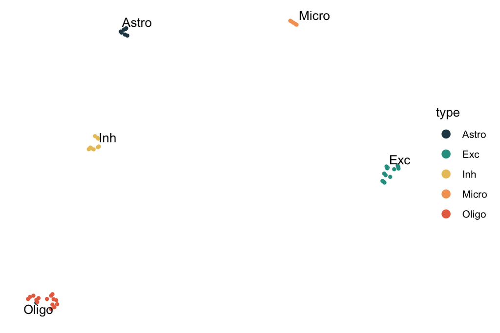

```r
obj@metadata[["type"]] <- dplyr::recode(obj@metadata[["cluster_id"]],
                                        "1" = "Astro",
                                        "2" = "Exc",
                                        "3" = "Micro",
                                        "4" = "Oligo",
                                        "5" = "Inh")
library(ggrepel)
dimFeature(obj, colorBy = type, colors = pal, pointSize = 1)  +
  geom_text_repel(aes(label = type), color = "black", data = obj@metadata |> dplyr::group_by(type) |> dplyr::summarise(umap_x = median(umap_x), umap_y = median(umap_y)))
```

You might also want cluster tracks with the group name:

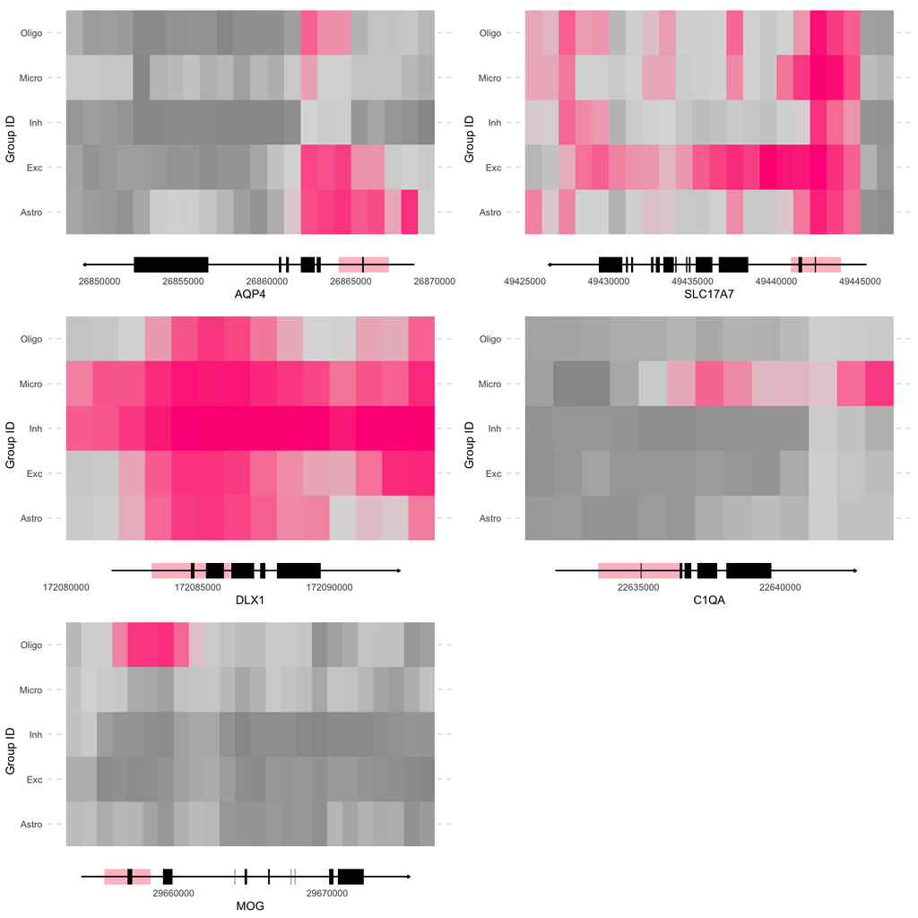

```r
obj@genomeMatrices[["cg_type_tracks"]] <- copy(obj@genomeMatrices[["cg_cluster_tracks"]])
setnames(obj@genomeMatrices[["cg_type_tracks"]], c("chr", "start", "end", "Astro", "Exc", "Micro", "Oligo", "Inh"))
heatMap(obj,
        genes = c("AQP4", "SLC17A7","DLX1", "C1QA", "MOG"),
        matrix = "cg_type_tracks",
        nrow = 3,
        legend = FALSE,
        width = 1000)
```

### DIFFERENTIALLY METHYLATED REGION ANALYSIS

There are two main formats to set up DMR analysis. The first is to test DMRs for each cluster against all others. Only the sum matrix (which we saved at the calcSmoothedWindows step) is needed:

```r
dmrs <- testDMR(cluster1kbwindows[["sum_matrix"]], eachVsAll = TRUE, nminTotal = 5, nminGroup = 5)
```

```
##
## Finished group 1
## Finished group 2
## Finished group 3
## Finished group 4
## Finished group 5
```

Then expand and filter the resulting list according to the desired stringency.

```r
dmrs <- filterDMR(dmrs, method = "bonferroni", filter = TRUE, pThreshold = 0.01, logThreshold = 2)
head(dmrs)
```

```
##       chr   start     end   test         pval   logFC         padj direction
##    <char>   <num>   <num> <fctr>        <num>   <num>        <num>    <char>
## 1:   chr1 2527000 2528000      1 3.379113e-13 -2.1883 4.484437e-06      hypo
## 2:   chr1 2531000 2532000      1 1.468306e-17 -2.3961 1.948595e-10      hypo
## 3:   chr1 3067000 3068000      1 2.395905e-55 -3.1432 3.179617e-48      hypo
## 4:   chr1 3068000 3069000      1 1.631397e-34 -3.3731 2.165035e-27      hypo
## 5:   chr1 3070000 3071000      1 4.779836e-29 -2.3613 6.343344e-22      hypo
## 6:   chr1 3071000 3072000      1 2.688662e-52 -2.8462 3.568136e-45      hypo
```

Especially since the matrix is smoothed, adjacent genomic windows may be significant. You can collapse them with the following function. If annotation = T, any overlapping genes will be noted in the results table.

```r
collapsed_dmrs <- collapseDMR(obj, dmrs, maxDist = 4000, minLength = 2000, reduce = T, annotate = T)
head(collapsed_dmrs)
```

```
## Key: <chr, dmr_start, dmr_end>
##       chr dmr_start dmr_end   test direction dmr_length     dmr_padj dmr_logFC
##    <char>     <num>   <num> <fctr>    <char>      <num>        <num>     <num>
## 1:   chr1    997000 1000000      3      hypo       3000 5.047502e-15   -2.6817
## 2:   chr1   1431000 1434000      4      hypo       3000 5.695319e-65   -2.7787
## 3:   chr1   2232000 2235000      3      hypo       3000 4.729254e-19   -4.2955
## 4:   chr1   2527000 2532000      1      hypo       5000 1.948595e-10   -2.3961
## 5:   chr1   3063000 3066000      3      hypo       3000 1.481495e-55   -2.8111
## 6:   chr1   3067000 3080000      1      hypo      13000 2.225694e-97   -3.3731
##               gene_names
##                   <char>
## 1: ENSG00000272512, HES4
## 2:             LINC01770
## 3:                   SKI
## 4: HES5, ENSG00000272449
## 5:             PRDM16-DT
## 6:     PRDM16-DT, PRDM16
```

Note: The “test” column indicates which cluster is considered the member group. If you are testing a renamed matrix, you might want to add those names To your results instead of having the numerical order in which they were tested (which works ok for cluster DMRs).

```r
key <- data.frame(test = as.factor(1:5),
                 type = c("Astro", "Exc", "Micro", "Oligo", "Inh"))
collapsed_dmrs <- left_join(collapsed_dmrs, key, by = "test")
head(collapsed_dmrs)
```

```
## Key: <chr, dmr_start, dmr_end>
##       chr dmr_start dmr_end   test direction dmr_length     dmr_padj dmr_logFC
##    <char>     <num>   <num> <fctr>    <char>      <num>        <num>     <num>
## 1:   chr1    997000 1000000      3      hypo       3000 5.047502e-15   -2.6817
## 2:   chr1   1431000 1434000      4      hypo       3000 5.695319e-65   -2.7787
## 3:   chr1   2232000 2235000      3      hypo       3000 4.729254e-19   -4.2955
## 4:   chr1   2527000 2532000      1      hypo       5000 1.948595e-10   -2.3961
## 5:   chr1   3063000 3066000      3      hypo       3000 1.481495e-55   -2.8111
## 6:   chr1   3067000 3080000      1      hypo      13000 2.225694e-97   -3.3731
##               gene_names   type
##                   <char> <char>
## 1: ENSG00000272512, HES4  Micro
## 2:             LINC01770  Oligo
## 3:                   SKI  Micro
## 4: HES5, ENSG00000272449  Astro
## 5:             PRDM16-DT  Micro
## 6:     PRDM16-DT, PRDM16  Astro
```

If specific comparisons are desired, a data frame can be provided describing the tests. Three columns should be included: One listing members of group A, one listing members of group B, and one with the name of the test.

```r
comparisons <- data.frame(
  stringsAsFactors = FALSE,
              name = c("test1", "test2", "test3"),
                 A = c("1,2,3", "1", "2,3"),
                 B = c("1,4", "2", "1")
)
dmrs <- testDMR(sumMatrix = cluster1kbwindows[["sum_matrix"]], comparisons = comparisons, nminTotal = 5, nminGroup = 5)
```

### INVESTIGATING DMR RESULTS

First, let’s look at how many DMRs were identified in each group:

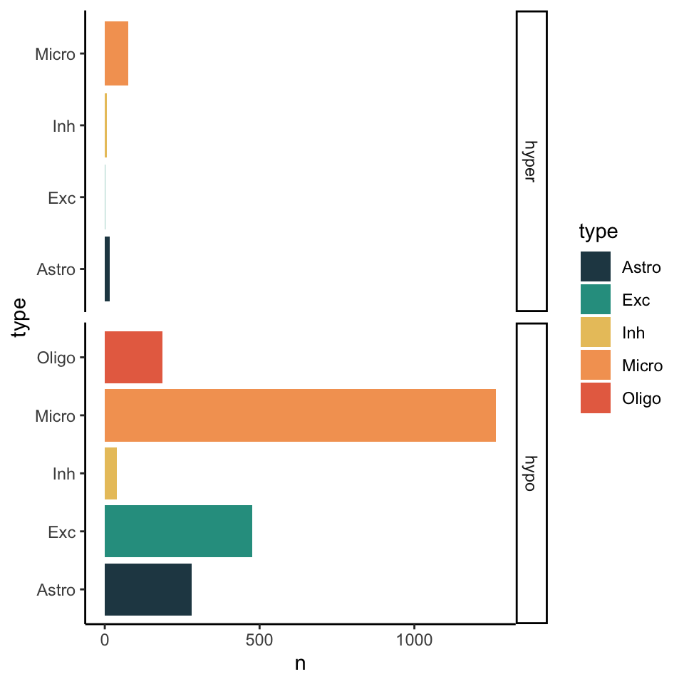

```r
ggplot(collapsed_dmrs |> dplyr::group_by(type, direction) |> dplyr::summarise(n = n()),
       aes(y = type, x = n, fill = type)) + geom_col() +
  facet_grid(vars(direction), scales = "free_y") + scale_fill_manual(values = pal) + theme_classic()
```

It can be helpful to select top results per group. Below is a method for choosing the lowest combined rank based on adjusted p value and logFC:

```r
top_dmrs <- collapsed_dmrs |>
  dplyr::group_by(type, direction) |>
  dplyr::arrange(dmr_padj, .by_group = TRUE) |> dplyr::mutate(rank_padj = 1:n()) |>
  dplyr::arrange(desc(abs(dmr_logFC)), .by_group = TRUE) |> dplyr::mutate(rank_logFC = 1:n()) |>
  rowwise() |> dplyr::mutate(total_rank = sum(rank_padj, rank_logFC)) |>
  group_by(test, direction) |> slice_min(n = 1, order_by = total_rank) |>
  dplyr::mutate(location = paste0(chr, "_", (dmr_start - 2000), "_", (dmr_end + 2000))) |> dplyr::arrange(direction)
```

Plotting top hypomethylated regions for each group demonstrates that top DMRs often fall over canonical marker genes:

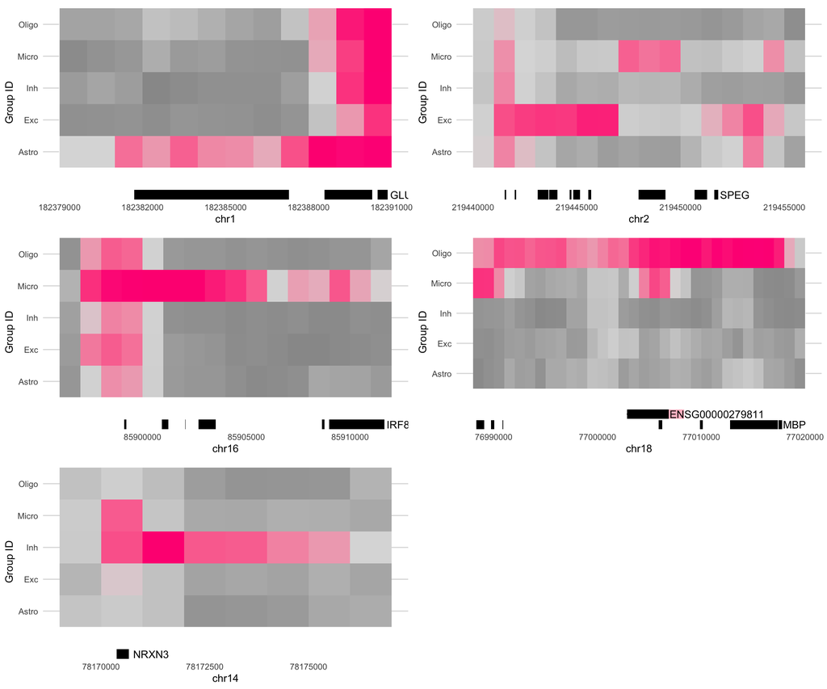

```r
heatMap(obj, matrix = "cg_type_tracks", regions = top_dmrs$location[top_dmrs$direction == "hypo"], nrow = 3, legend = FALSE, width = 1000, arrowOverhang = 0)
```

### GO ANALYSIS

Further interpretation of the results can be explored using a wide variety of packages available on R. In this example, we will use the topGO package to test for Gene Ontology (GO) term enrichments for genes with hypomethylated regions in the excitatory neuron group.

```r
library(topGO)
```

```r
library(org.Hs.eg.db)
background <- unique(obj@ref |> dplyr::filter(type == "gene" & gene_type == "protein_coding" & seqid != "chrM") |> dplyr::pull(gene_name))
query <- unlist(strsplit(collapsed_dmrs$gene_names[collapsed_dmrs$type == "Exc" & collapsed_dmrs$direction == "hypo"], ", "))

GOdata <- new("topGOdata",
              description = "GO Enrichment Analysis",
              ontology = "BP",
              allGenes = setNames(factor(as.integer(background %in% query), levels = c(0, 1)), background),
              geneSel = function(x) x == 1,
              nodeSize = 10,
              annot = annFUN.org,
              mapping = "org.Hs.eg.db",
              ID = "symbol")
resultElim <- runTest(GOdata, algorithm = "elim", statistic = "fisher")
resultElim <- GenTable(GOdata, Fisher = resultElim, topNodes = 500, numChar = 60)
resultElim <- resultElim |> dplyr::filter(Fisher < 0.01 & Significant > 7) |> dplyr::mutate(fold_change = Significant/Expected, Fisher = as.numeric(Fisher)) |> dplyr::filter(fold_change > 2)
resultElim <- janitor::clean_names(resultElim)
```

As expected, top results are strongly related to excitatory synaptic transmission:

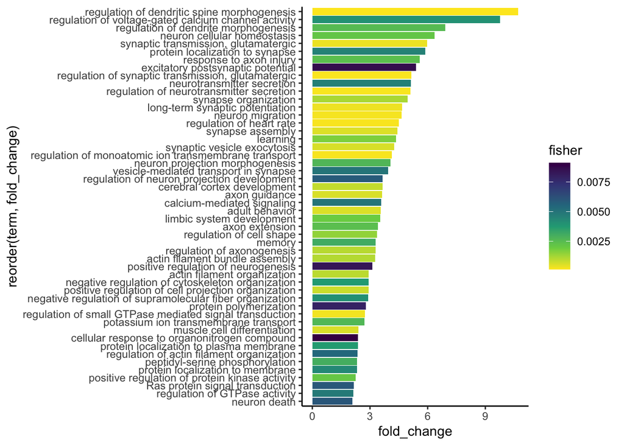

```r
ggplot(resultElim, aes(x = fold_change, y = reorder(term, fold_change), fill = fisher)) + geom_col() + theme_classic() + scale_fill_viridis_c(direction = -1)
```

Optional: Reducing redundancy can be helpful for visualizing GO results more holistically

```r
suppressMessages(library(rrvgo))
simMatrix <- calculateSimMatrix(resultElim$go_id, orgdb="org.Hs.eg.db", ont="BP", method="Rel")
```

```
## preparing gene to GO mapping data...
```

```
## preparing IC data...
```

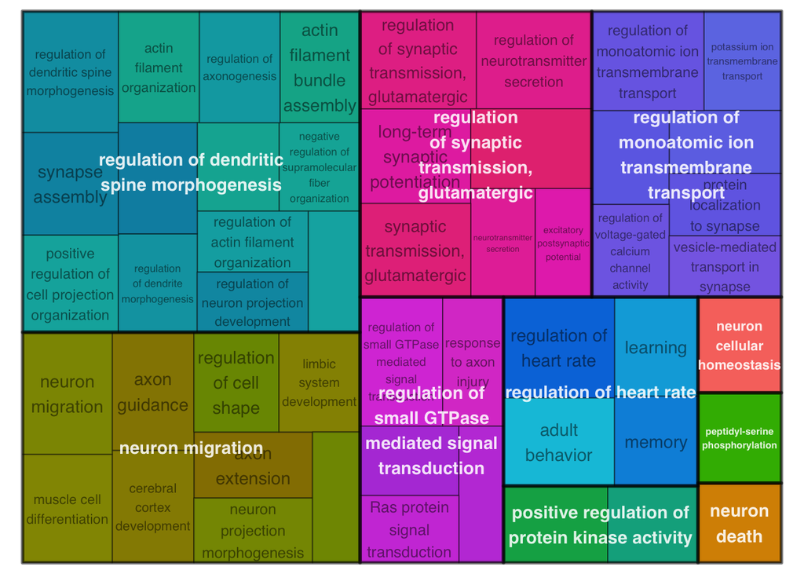

```r
scores <- setNames(-log10(resultElim$fisher), resultElim$go_id)
reducedTerms <- reduceSimMatrix(simMatrix,scores, threshold=0.9, orgdb="org.Hs.eg.db")
treemapPlot(reducedTerms)
```

### CONCLUSION

Thanks for trying out Amethyst! Additional utilities are still to come. We are also open to suggestions. Good luck in your analysis!